# Self-Driving Car Engineer Nanodegree

## Project: Build a Traffic Sign Recognition Classifier

In this notebook, a template is provided for you to implement your functionality in stages, which is required to successfully complete this project. If additional code is required that cannot be included in the notebook, be sure that the Python code is successfully imported and included in your submission if necessary.

In addition to implementing code, there is a writeup to complete. The writeup should be completed in a separate file, which can be either a markdown file or a pdf document. There is a [write up template](https://github.com/udacity/CarND-Traffic-Sign-Classifier-Project/blob/master/writeup_template.md) that can be used to guide the writing process. Completing the code template and writeup template will cover all of the [rubric points](https://review.udacity.com/#!/rubrics/481/view) for this project.

The [rubric](https://review.udacity.com/#!/rubrics/481/view) contains "Stand Out Suggestions" for enhancing the project beyond the minimum requirements. The stand out suggestions are optional. If you decide to pursue the "stand out suggestions", you can include the code in this Ipython notebook and also discuss the results in the writeup file.

> **Note:** Code and Markdown cells can be executed using the **Shift + Enter** keyboard shortcut. In addition, Markdown cells can be edited by typically double-clicking the cell to enter edit mode.

## Step 0: Load The Data

```python
# Load pickled data
import pickle

# TODO: Fill this in based on where you saved the training and testing data

training_file = '../data/train.p'
validation_file= '../data/valid.p'
testing_file = '../data/test.p'

with open(training_file, mode='rb') as f:
    train = pickle.load(f)
with open(validation_file, mode='rb') as f:
    valid = pickle.load(f)
with open(testing_file, mode='rb') as f:
    test = pickle.load(f)

X_train, y_train = train['features'], train['labels']
X_valid, y_valid = valid['features'], valid['labels']
X_test, y_test = test['features'], test['labels']
```

### Asserting the sizes of data are the same

```python
assert(len(X_train) == len(y_train))
assert(len(X_valid) == len(y_valid))
assert(len(X_test) == len(y_test))
```

## Step 1: Dataset Summary & Exploration

The pickled data is a dictionary with 4 key/value pairs:

- `'features'` is a 4D array containing raw pixel data of the traffic sign images, (num examples, width, height, channels).
- `'labels'` is a 1D array containing the label/class id of the traffic sign. The file `signnames.csv` contains id -> name mappings for each id.
- `'sizes'` is a list containing tuples, (width, height) representing the original width and height the image.
- `'coords'` is a list containing tuples, (x1, y1, x2, y2) representing coordinates of a bounding box around the sign in the image. **THESE COORDINATES ASSUME THE ORIGINAL IMAGE. THE PICKLED DATA CONTAINS RESIZED VERSIONS (32 by 32) OF THESE IMAGES**

Complete the basic data summary below. Use python, numpy and/or pandas methods to calculate the data summary rather than hard coding the results. For example, the [pandas shape method](http://pandas.pydata.org/pandas-docs/stable/generated/pandas.DataFrame.shape.html) might be useful for calculating some of the summary results.

### Provide a Basic Summary of the Data Set Using Python, Numpy and/or Pandas

```python
print(X_train.shape, y_train.shape)
print(X_valid.shape, y_valid.shape)
print(X_test.shape, y_test.shape)
```

```
(34799, 32, 32, 3) (34799,)
(4410, 32, 32, 3) (4410,)
(12630, 32, 32, 3) (12630,)
```

```python
### Replace each question mark with the appropriate value.
### Use python, pandas or numpy methods rather than hard coding the results
import numpy as np
import pandas as pd

# TODO: Number of training examples
n_train = X_train.shape[0]

# TODO: Number of validation examples
n_validation = X_valid.shape[0]

# TODO: Number of testing examples.
n_test = X_test.shape[0]

# TODO: What's the shape of an traffic sign image?
image_shape = X_test.shape[1:3]

# TODO: How many unique classes/labels there are in the dataset.
n_classes = len(np.unique(y_valid))

print("Number of training examples =", n_train)
print("Number of testing examples =", n_test)
print("Image data shape =", image_shape)
print("Number of classes =", n_classes)
```

```
Number of training examples = 34799
Number of testing examples = 12630
Image data shape = (32, 32)
Number of classes = 43
```

### Include an exploratory visualization of the dataset

Visualize the German Traffic Signs Dataset using the pickled file(s). This is open ended, suggestions include: plotting traffic sign images, plotting the count of each sign, etc.

The [Matplotlib](http://matplotlib.org/) [examples](http://matplotlib.org/examples/index.html) and [gallery](http://matplotlib.org/gallery.html) pages are a great resource for doing visualizations in Python.

**NOTE:** It's recommended you start with something simple first. If you wish to do more, come back to it after you've completed the rest of the sections. It can be interesting to look at the distribution of classes in the training, validation and test set. Is the distribution the same? Are there more examples of some classes than others?

```python
### Data exploration visualization code goes here.
### Feel free to use as many code cells as needed.
import matplotlib.pyplot as plt
import seaborn as sns
# Visualizations will be shown in the notebook.
%matplotlib inline
```

### Creating dictionary for sign names

```python
sign_names_dict = pd.read_csv('signnames.csv') # Reading signnames.csv
sign_names_dict.drop('ClassId', axis=1, inplace=True) # Drop the ClassId column, since the index serves the same role
sign_names_dict = sign_names_dict.to_dict()['SignName'] # Transform into a python dictionary
```

### Plotting the traffic sign images

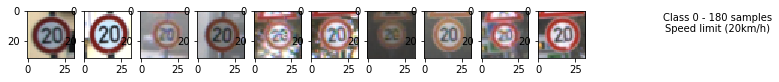

[figure not shown]

[figure not shown]

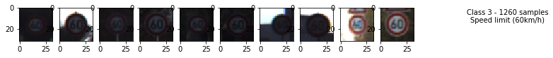

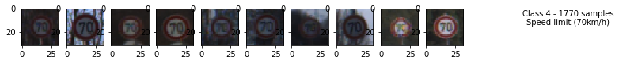

[figure not shown]

[figure not shown]

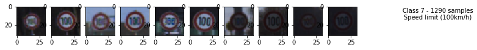

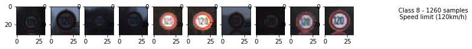

[figure not shown]

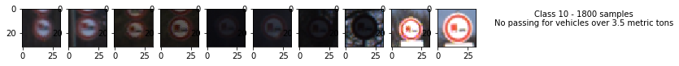

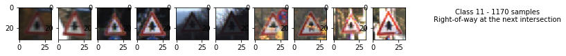

[31 more figures not shown]

```python
# Plotting 43 classes from the train images
for i in range(n_classes):
    class_idxs_list = np.where(y_train == i)[0] # Grab all indices of a class
    class_idxs = class_idxs_list[0:150:15] # Grab 10 indices from a class
    class_length = len(class_idxs_list)

    #print('Class {} - {} | {} samples'.format(i, sign_names_dict[i], class_length))

    fig = plt.figure(figsize=(10, 1))
    for j, idx in enumerate(class_idxs):
        fig.add_subplot(1, 10, j+1) # j+1 since pyplot only takes the arg of >0
        if (j%9==0) & (j!=0):
            plt.ylabel('Class {} - {} samples\n{}'.format(i, class_length, sign_names_dict[i]),
                       rotation=360,
                       labelpad=-200)
        plt.imshow(X_train[idx])
    plt.show()
```

### Plotting the data distribution

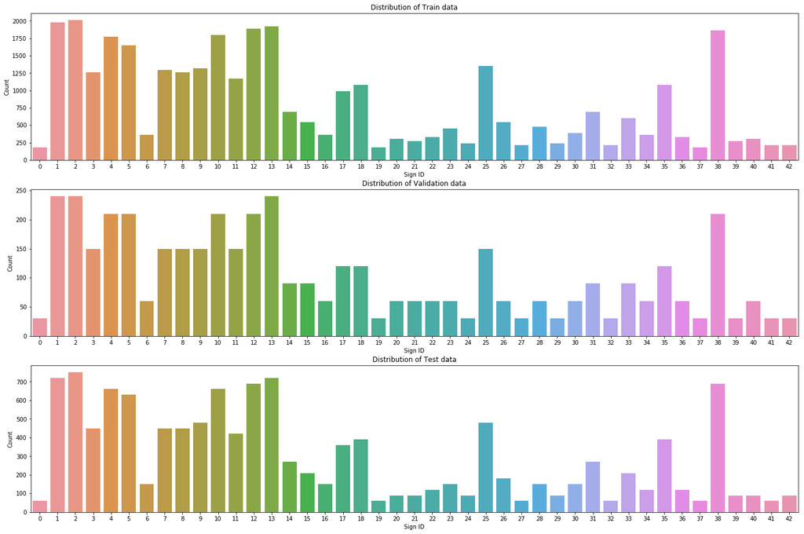

```python
fig = plt.figure(figsize=(24, 16))
for i, label in enumerate([y_train, y_valid, y_test]):
    fig.add_subplot(3, 1, i+1) # i+i since pyplot only takes the argument of > 0
    sns.countplot(label)
    plt.title('Distribution of {} data'.format(['Train', 'Validation', 'Test'][i]))
    plt.xlabel('Sign ID')
    plt.ylabel('Count')
```

## Step 2: Design and Test a Model Architecture

Design and implement a deep learning model that learns to recognize traffic signs. Train and test your model on the [German Traffic Sign Dataset](http://benchmark.ini.rub.de/?section=gtsrb&subsection=dataset).

The LeNet-5 implementation shown in the classroom at the end of the CNN lesson is a solid starting point. You'll have to change the number of classes and possibly the preprocessing, but aside from that it's plug and play!

With the LeNet-5 solution from the lecture, you should expect a validation set accuracy of about 0.89. To meet specifications, the validation set accuracy will need to be at least 0.93. It is possible to get an even higher accuracy, but 0.93 is the minimum for a successful project submission.

There are various aspects to consider when thinking about this problem:

- Neural network architecture (is the network over or underfitting?)
- Play around preprocessing techniques (normalization, rgb to grayscale, etc)
- Number of examples per label (some have more than others).
- Generate fake data.

Here is an example of a [published baseline model on this problem](http://yann.lecun.com/exdb/publis/pdf/sermanet-ijcnn-11.pdf). It's not required to be familiar with the approach used in the paper but, it's good practice to try to read papers like these.

### Pre-process the Data Set (normalization, grayscale, etc.)

Minimally, the image data should be normalized so that the data has mean zero and equal variance. For image data, `(pixel - 128)/ 128` is a quick way to approximately normalize the data and can be used in this project.

Other pre-processing steps are optional. You can try different techniques to see if it improves performance.

Use the code cell (or multiple code cells, if necessary) to implement the first step of your project.

### Helper functions for images preprocessing

```python
def normalize(img):
    """
    Normalize image object.
    INPUT
    img (image object) - An image object
    OUTPUT
    norm_img (image object) - An image object normalized
    """
    # Normalizing: (x - mean)/standard_deviation
    norm_img = (img - img.mean(axis=(0,1))) / img.std(axis=(0,1))
    return norm_img

def v_normalize(img_data):
    """
    Normalize image data.
    INPUT
    img_data (numpy array) - A numpy array of image objects
    norm_img_data (numpy array) - A numpy array of normalized image objects
    """
    norm_img_data = np.array(list(map(normalize, img_data))) # Map grayscale to all images

    return norm_img_data

def grayscale(img):
    """
    Turn an RGB image into grayscale.
    INPUT
    img (img object) - An RGB image object
    OUTPUT
    gray_img (img object) - A grayscale image object
    """
    # Following what scikit image would do:
    # https://scikit-image.org/docs/dev/auto_examples/color_exposure/plot_rgb_to_gray.html
    gray_img = (0.2125*img[:,:,0])  + (0.7154*img[:,:,1])  + (0.0721*img[:,:,2])

    return gray_img

def v_grayscale(img_data):
    """
    Turn RGB image data array with Numpy vector operation
    INPUT
    img_data (numpy array) - A numpy array of image objects
    OUTPUT
    gray_img_data (numpy array) = A numpy array of image objects grayscaled
    """
    gray_img_data = np.array(list(map(grayscale, img_data))) # Map grayscale to all images

    return gray_img_data

def reshape(img_data):
    """
    Reshape the dataset shape by wrapping the last element in a list.
    INPUT
    img_data (img dataset)
    OUTPUT
    reshaped_img (img dataset)
    """
    n = img_data.shape[0] # Number of images
    k = img_data.shape[1] # Width & height of an image
    reshaped_img_data = np.reshape(img_data, (n, k, k, 1))

    return reshaped_img_data

def preprocess(img_data):
    """
    Pipeline for preprocessing image dataset for the input of model training.
    INPUT
    img_data (img dataset)
    OUTPUT
    result_img (img dataset)
    """
    gray_img = v_grayscale(img_data)
    norm_img = normalize(gray_img)
    result_img = reshape(norm_img)

    return result_img
```

### Visualize preprocessing steps

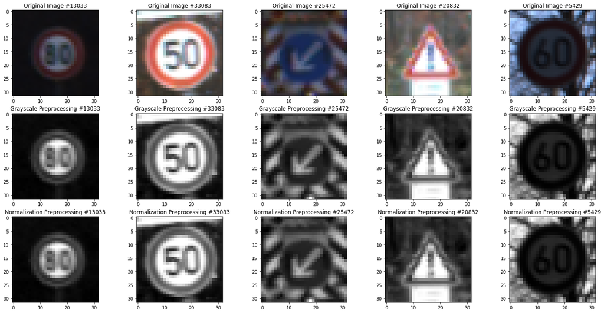

```python
np.random.seed(42)
example_images = []
example_idx = np.random.uniform(0, n_train, 5).astype(int)

for idx in example_idx:
    example_images.append(X_train[idx])
example_images = np.array(example_images)

# Visualizing grayscale & normalization
grayscale_examples = v_grayscale(example_images)
norm_examples = v_normalize(grayscale_examples)

fig = plt.figure(figsize=(24, 12))
for i in range(5):
    fig.add_subplot(3, 5, i+1)
    plt.imshow(example_images[i])
    plt.title('Original Image #{}'.format(example_idx[i]))
    fig.add_subplot(3, 5, i+6)
    plt.imshow(grayscale_examples[i], cmap='gray')
    plt.title('Grayscale Preprocessing #{}'.format(example_idx[i]))
    fig.add_subplot(3, 5, i+11)
    plt.imshow(norm_examples[i], cmap='gray')
    plt.title('Normalization Preprocessing #{}'.format(example_idx[i]))
```

### Preprocess the image training data

```python
### Preprocess the data here. It is required to normalize the data. Other preprocessing steps could include
### converting to grayscale, etc.
### Feel free to use as many code cells as needed.
from sklearn.utils import shuffle

X_train_processed = preprocess(X_train)
X_valid_processed = preprocess(X_valid)
X_test_processed = preprocess(X_test)

# Asserting the size of processed images
assert len(X_train_processed) == len(X_train)
assert len(X_valid_processed) == len(X_valid)
assert len(X_test_processed) == len(X_test)

# Shuffle training data
X_train_processed, y_train_processed = shuffle(X_train_processed, y_train)
```

```python
print(X_train_processed.shape)
print(X_test_processed.shape)
print(X_valid_processed.shape)
```

```
(34799, 32, 32, 1)
(12630, 32, 32, 1)
(4410, 32, 32, 1)
```

## Data Augmentation

### Helper functions for data augmentation

```python
from skimage.transform import AffineTransform
from skimage.transform import warp
from skimage import exposure
from skimage.util import random_noise
from tqdm import tqdm

# Set seed to the numpy random generator
np.random.seed(42)

def generate_image(img, n=1):
    """
    Generate fake image(s) by randomly rotate, translate,
    zoom, brighten/darken, and add noise to the image.

    INPUT:
    img (image object)
    n (int) - The number of images to be generated
    OUTPUT:
    generated_images (numpy array) - A numpy array consisted of generated images
    """
    generated_images = []
    for i in range(n):
        # Create matrix transformation
        M = AffineTransform(shear=np.random.uniform(-.05,.05),
                            translation=(np.random.uniform(-2,2), np.random.uniform(-2,2)),
                            scale=(np.random.uniform(0.9,1.1), np.random.uniform(0.9, 1.1)),
                            rotation=np.random.uniform(-np.pi/12, np.pi/12))

        gen_img = warp(img, M, mode='edge')
        gen_img = exposure.adjust_gamma(gen_img, gamma=np.random.uniform(0.5, 1.5))
#         gen_img = random_noise(gen_img, var=0.005) # Set Gaussian variance to 0.005 to minimize noise

        generated_images.append(gen_img)

    return generated_images

class GenerateAugmentImages:
    """
    Generator to output an image augmentation dataset.
    """
    def __init__(self):
        """
        Initialize instance with attribute:
        self.image_data (numpy array) - Array of image objects
        self.image_label (numpy array) - Array of image labels
        self.label_unique_count (dictionary) - Dictionary of class counts
        """
        self.image_data_source = None
        self.image_label = None
        self.label_unique_count = None

    def feed(self, images_data, images_label):
        """
        Feed image data and their labels to the generator.
        """
        self.image_data_source = images_data.copy()
        self.image_label = images_label.copy()

        # Calculate image label count
        label, count = np.unique(self.image_label,
                                 return_counts=True)
        self.label_unique_count = dict(zip(label, count))

        print('Data saved in generator')

    def calc_augment_size(self):
        """
        Returns the number of augment images to be
        generated per class
        """
        assert (self.label_unique_count != None), 'Error: Image label count is empty'

        augment_size = self.label_unique_count.copy()
        max_count = max(augment_size.values())

        for key in augment_size:
            size = int(max_count/augment_size[key])
            augment_size[key] = size

        return augment_size

    def generate_augment_dataset(self):
        """
        Generate augment dataset.
        """
        assert (self.image_data_source != None), 'Error: Image data is empty'

        # Set seed to the numpy random generator
        np.random.seed(42)

        augment_image = []
        augment_label = []

        augment_size = self.calc_augment_size()

        # Iterate over image data
        for idx, img in enumerate(tqdm(self.image_data_source)): # The tqdm progress is not accurate, it takes a lot longer after tqdm shows done
            class_id = self.image_label[idx]
            num_generate = augment_size[class_id]

            augment_image += generate_image(img, num_generate)
            augment_label += [class_id for j in range(num_generate)]

        # Convert list to numpy array
        augment_image = np.array(augment_image)
        augment_label = np.array(augment_label)

        print('Generating augment dataset is done')

        return augment_image, augment_label
```

### Visualize augmentation techniques output

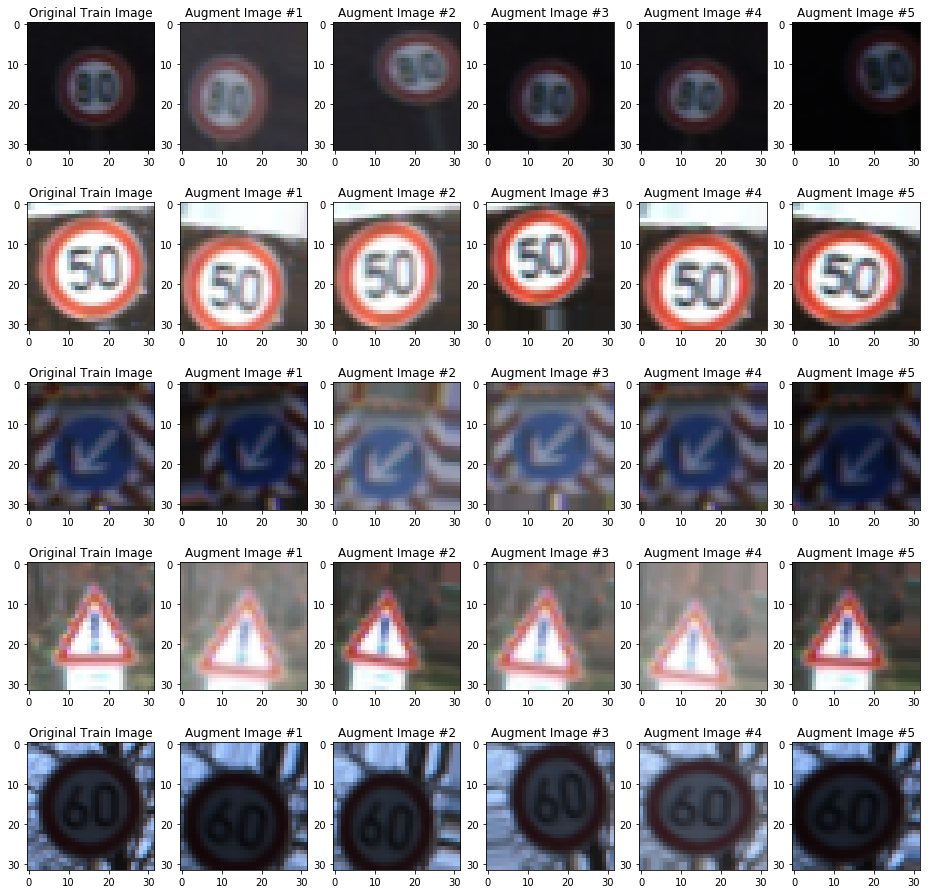

```python
np.random.seed(42)

fig = plt.figure(figsize=(16, 16))
for i, img in enumerate(example_images):
    # Visualize the original train image
    plt.subplot(5, 6, (i*6)+1)
    plt.imshow(img)
    plt.title('Original Train Image')

    # Generating 5 augmentation images
    augment_examples = generate_image(img, n=5)

    # Visualize the augmentation images
    for j, img_augment in enumerate(augment_examples):
        plt.subplot(5, 6, (i*6) + j + 2)
        plt.imshow(img_augment)
        plt.title('Augment Image #{}'.format(j+1))
```

### Instantiate generator

```python
augment_generator = GenerateAugmentImages()
augment_generator.feed(X_train, y_train)
```

```
Data saved in generator
```

### Generate augmentation dataset

```python
X_augment, y_augment = augment_generator.generate_augment_dataset()
```

```
Generating augment dataset is done
```

### Explore augmentation dataset

```python
n_augment = len(X_augment)

# Data shape
print(X_augment.shape, y_augment.shape)
print('Augment data size: {}'.format(n_augment))
```

```
(74217, 32, 32, 3) (74217,)
Augment data size: 74217
```

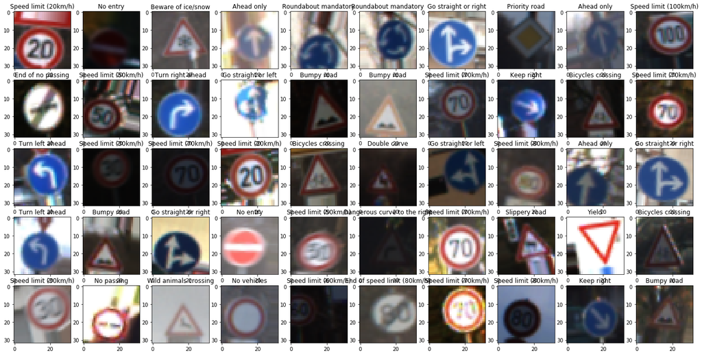

```python
# Visualize random 50 images in the augmentation dataset
np.random.seed(42)
sample_idx = np.random.uniform(0, X_augment.shape[0], 50).astype(int)

fig = plt.figure(figsize=(24, 12))
for i, idx in enumerate(sample_idx):
    plt.subplot(5, 10, i+1)
    plt.imshow(X_augment[idx])
    class_id = y_augment[idx]
    plt.title('{}'.format(sign_names_dict[class_id]))
```

### Save (or load) the augmentation dataset

```python
### Don't run this cell on Udacity Workspace: it might max out its space (>3GB).

augment_file = '../data/augment.p'
try:
    augment_object = {'features': X_augment, 'labels': y_augment}

    f = open(augment_file, 'wb')
    pickle.dump(augment_object,f)
    f.close()
except NameError:
    with open(augment_file, mode='rb') as f:
        augment = pickle.load(f)

    X_augment, y_augment = train['features'], train['labels']
```

### Preprocess augmented images

```python
# Preprocess the augmentation images
X_augment_processed = preprocess(X_augment)

# Shuffle them before merged to training dataset
X_augment_shuffled, y_augment_shuffled = shuffle(X_augment_processed, y_augment)
```

```python
# Merging original datasets with the augmented ones
# (might take a while)
X_train_merged = np.append(X_train_processed, X_augment_shuffled, axis=0)
y_train_merged = np.append(y_train_processed, y_augment_shuffled, axis=0)

# Reshuffle the dataset
X_train_merged, y_train_merged = shuffle(X_train_merged, y_train_merged)

print(X_train_merged.shape, y_train_merged.shape)
```

```
(109016, 32, 32, 1) (109016,)
```

### Visualize merged train dataset

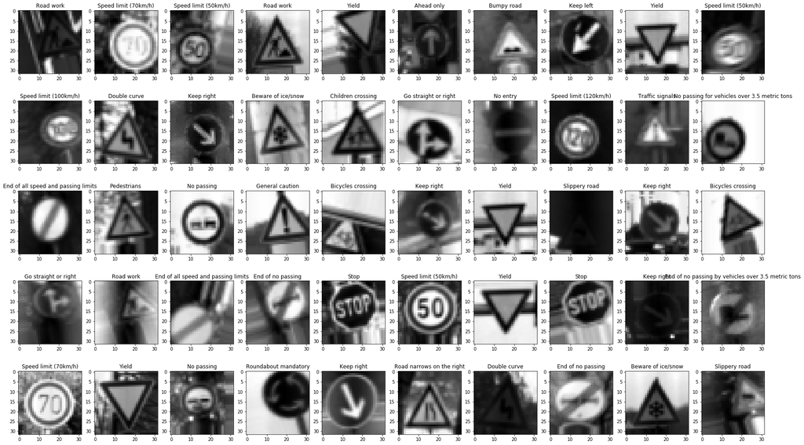

```python
# Visualize random 50 images in the augmentation dataset
np.random.seed(42)
sample_idx = np.random.uniform(0, X_train_merged.shape[0], 50).astype(int)

fig = plt.figure(figsize=(30, 18))
for i, idx in enumerate(sample_idx):
    plt.subplot(5, 10, i+1)
    img = np.reshape(X_train_merged[idx], (32, 32)) # Reshape, so it could be drawn
    plt.imshow(img, cmap='gray')
    class_id = y_train_merged[idx]
    plt.title('{}'.format(sign_names_dict[class_id]))
```

### Visualize the new dataset distribution

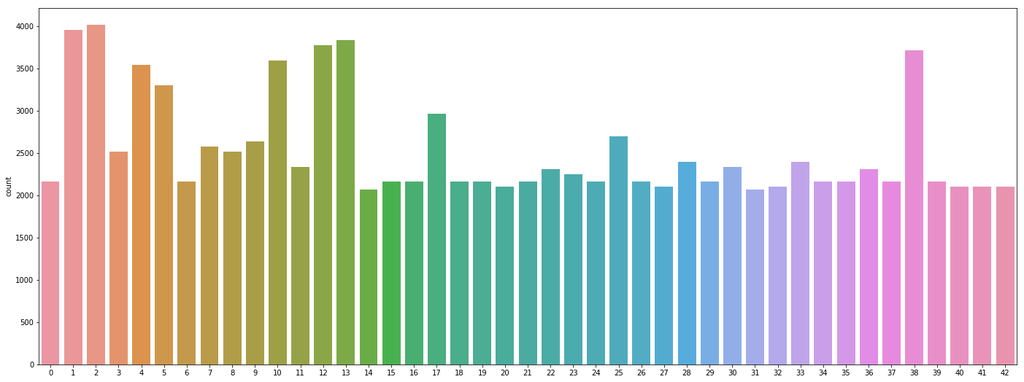

```python
fig = plt.figure(figsize=(24,9))
sns.countplot(y_train_merged)
```

### Model Architecture

```python
### Define your architecture here.
### Feel free to use as many code cells as needed.
import tensorflow as tf
from tensorflow.contrib.layers import flatten

def conv2d(x, W, b, strides=1):
    x = tf.nn.conv2d(x, W, strides=[1, strides, strides, 1], padding='VALID')
    x = tf.nn.bias_add(x, b)
    return x

def maxpool2d(x, k=2):
    return tf.nn.max_pool(
        x,
        ksize=[1, k, k, 1],
        strides=[1, k, k, 1],
        padding='SAME')

def LeNet(x):
    # Arguments used for tf.truncated_normal, randomly defines variables for the weights and biases for each layer
    mu = 0
    sigma = 0.1

    # TODO: Layer 1: Convolutional. Input = 32x32x1. Output = 28x28x6.
    conv1_W = tf.Variable(tf.truncated_normal([5, 5, 1, 6], mean=mu, stddev=sigma))
    conv1_b = tf.Variable(tf.zeros(6))
    conv1 = conv2d(x, conv1_W, conv1_b)

    # TODO: Activation.
    conv1 = tf.nn.relu(conv1)

    # TODO: Pooling. Input = 28x28x6. Output = 14x14x6.
    conv1 = maxpool2d(conv1)

    # TODO: Layer 2: Convolutional. Output = 10x10x16.
    conv2_W = tf.Variable(tf.truncated_normal([5, 5, 6, 16], mean=mu, stddev=sigma))
    conv2_b = tf.Variable(tf.zeros(16))
    conv2 = conv2d(conv1, conv2_W, conv2_b)

    # TODO: Activation.
    conv2 = tf.nn.relu(conv2)

    # TODO: Pooling. Input = 10x10x16. Output = 5x5x16.
    conv2 = maxpool2d(conv2)

    # TODO: Flatten. Input = 5x5x16. Output = 400.
    flat = flatten(conv2)

    # TODO: Layer 3: Fully Connected. Input = 400. Output = 120.
    fc1_W = tf.Variable(tf.truncated_normal([400, 120], mean=mu, stddev=sigma))
    fc1_b = tf.Variable(tf.zeros(120))
    fc1 = tf.add(tf.matmul(flat, fc1_W), fc1_b)

    # TODO: Activation.
    fc1 = tf.nn.relu(fc1)

    # TODO: Dropout.
    fc1 = tf.nn.dropout(fc1, keep_prob)

    # TODO: Layer 4: Fully Connected. Input = 120. Output = 84.
    fc2_W = tf.Variable(tf.truncated_normal([120, 84], mean=mu, stddev=sigma))
    fc2_b = tf.Variable(tf.zeros(84))
    fc2 = tf.add(tf.matmul(fc1, fc2_W), fc2_b)

    # TODO: Activation.
    fc2 = tf.nn.relu(fc2)

    # TODO: Dropout.
    fc2 = tf.nn.dropout(fc2, keep_prob)

    # TODO: Layer 5: Fully Connected. Input = 84. Output = 43.
    fc3_W = tf.Variable(tf.truncated_normal([84, 43], mean=mu, stddev=sigma))
    fc3_b = tf.Variable(tf.zeros(n_classes))
    logits = tf.add(tf.matmul(fc2, fc3_W), fc3_b)

    return logits
```

### Training Pipeline

```python
tf.reset_default_graph()

# Parameters
rate = 0.0005
EPOCHS = 150
BATCH_SIZE = 128
keep_prob = tf.placeholder(tf.float32) # probability to keep units

# Features and Labels
x = tf.placeholder(tf.float32, (None, 32, 32, 1))
y = tf.placeholder(tf.int32, (None))
one_hot_y = tf.one_hot(y, n_classes)

# Training Pipeline
logits = LeNet(x)
cross_entropy = tf.nn.softmax_cross_entropy_with_logits(labels=one_hot_y, logits=logits)
loss_operation = tf.reduce_mean(cross_entropy)
optimizer = tf.train.AdamOptimizer(learning_rate = rate)
training_operation = optimizer.minimize(loss_operation)
```

### Model Evaluation

```python
correct_prediction = tf.equal(tf.argmax(logits, 1), tf.argmax(one_hot_y, 1))
accuracy_operation = tf.reduce_mean(tf.cast(correct_prediction, tf.float32))

def evaluate(X_data, y_data):
    num_examples = len(X_data)
    total_accuracy = 0
    sess = tf.get_default_session()
    for offset in range(0, num_examples, BATCH_SIZE):
        batch_x, batch_y = X_data[offset:offset+BATCH_SIZE], y_data[offset:offset+BATCH_SIZE]
        accuracy = sess.run(accuracy_operation, feed_dict={x: batch_x, y: batch_y, keep_prob:1.0})
        total_accuracy += (accuracy * len(batch_x))
    return total_accuracy / num_examples
```

### Train, Validate and Test the Model

A validation set can be used to assess how well the model is performing. A low accuracy on the training and validation sets imply underfitting. A high accuracy on the training set but low accuracy on the validation set implies overfitting.

```python
### Train your model here.
### Calculate and report the accuracy on the training and validation set.
### Once a final model architecture is selected,
### the accuracy on the test set should be calculated and reported as well.
### Feel free to use as many code cells as needed.
saver = tf.train.Saver()

with tf.Session() as sess:

    sess.run(tf.global_variables_initializer())
    num_examples = len(X_train_merged)

    print("Training...")
    print()
    for i in range(EPOCHS):
        X_train_merged, y_train_merged = shuffle(X_train_merged, y_train_merged)
        for offset in range(0, num_examples, BATCH_SIZE):
            end = offset + BATCH_SIZE
            batch_x, batch_y = X_train_merged[offset:end], y_train_merged[offset:end]
            sess.run(training_operation, feed_dict={x: batch_x, y: batch_y, keep_prob:0.5})

        training_accuracy = evaluate(X_train_merged, y_train_merged)
        validation_accuracy = evaluate(X_valid_processed, y_valid)
        print("EPOCH {} ...".format(i+1))
        print("Training Accuracy = {:.3f}".format(training_accuracy))
        print("Validation Accuracy = {:.3f}".format(validation_accuracy))
        print()

    saver.save(sess, './lenet')
    print("Model saved")
```

```
Training...

EPOCH 1 ...
Training Accuracy = 0.538
Validation Accuracy = 0.636

EPOCH 2 ...
Training Accuracy = 0.681
Validation Accuracy = 0.739

EPOCH 3 ...
Training Accuracy = 0.761
Validation Accuracy = 0.826

EPOCH 4 ...
Training Accuracy = 0.802
Validation Accuracy = 0.853

EPOCH 5 ...
Training Accuracy = 0.828
Validation Accuracy = 0.863

EPOCH 6 ...
Training Accuracy = 0.845
Validation Accuracy = 0.874

EPOCH 7 ...
Training Accuracy = 0.863
Validation Accuracy = 0.894

EPOCH 8 ...
Training Accuracy = 0.879
Validation Accuracy = 0.899

EPOCH 9 ...
Training Accuracy = 0.887
Validation Accuracy = 0.910

EPOCH 10 ...
Training Accuracy = 0.896
```

[output cut: 548 more lines]

```
Validation Accuracy = 0.962

EPOCH 148 ...
Training Accuracy = 0.986
Validation Accuracy = 0.964

EPOCH 149 ...
Training Accuracy = 0.986
Validation Accuracy = 0.962

EPOCH 150 ...
Training Accuracy = 0.986
Validation Accuracy = 0.959

Model saved
```

### Evaluate the model

```python
saver = tf.train.Saver()

with tf.Session() as sess:
    saver.restore(sess, './lenet')

    test_accuracy = evaluate(X_test_processed, y_test)
    print("Test Accuracy = {:.3f}".format(test_accuracy))
```

```
INFO:tensorflow:Restoring parameters from ./lenet
Test Accuracy = 0.937
```

## Step 3: Test a Model on New Images

To give yourself more insight into how your model is working, download at least five pictures of German traffic signs from the web and use your model to predict the traffic sign type.

You may find `signnames.csv` useful as it contains mappings from the class id (integer) to the actual sign name.

### Load and Output the Images

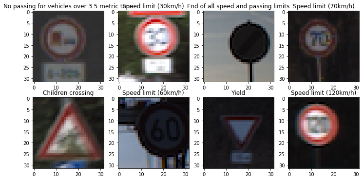

```python
### Load the images and plot them here.
### Feel free to use as many code cells as needed.
import matplotlib.pyplot as plt
import numpy as np
from glob import glob

new_images = []
new_images_labels = np.array([10, 1, 32, 4, 28, 3, 13, 8])

fig = plt.figure(figsize=(12, 6))
for i, im_path in enumerate(glob('./new_images/*.png')):
    img = plt.imread(im_path)
    new_images.append(np.array(img))
    title = sign_names_dict[new_images_labels[i]]
    plt.subplot(2, 4, i+1)
    plt.title(title)
    plt.imshow(img)

new_images = np.array(new_images)
```

#### Discussion on the new images

I collected the new images from the GTSDB dataset, which could be downloaded here: [GTSDB Dataset](https://benchmark.ini.rub.de/gtsdb_dataset.html).

I manually crop and resize the image to be 32x32 pixels and manually select ones which might pose a challenge to the model performance.

### Predict the Sign Type for Each Image

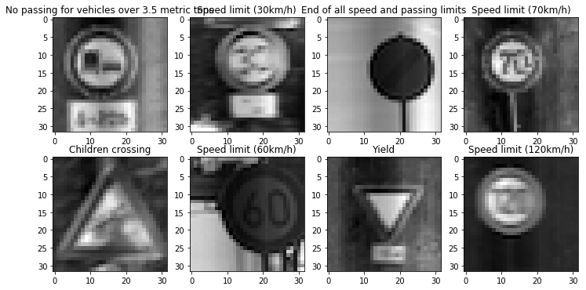

```python
### Run the predictions here and use the model to output the prediction for each image.
### Make sure to pre-process the images with the same pre-processing pipeline used earlier.
### Feel free to use as many code cells as needed.

# Preprocessing the new images
new_images_processed = preprocess(new_images)

# Visualize preprocessing outputs
fig = plt.figure(figsize=(12, 6))
for i, img in enumerate(new_images_processed):
    img = np.reshape(img, (32, 32))
    title = sign_names_dict[new_images_labels[i]]
    plt.subplot(2, 4, i+1)
    plt.title(title)
    plt.imshow(img, cmap='gray')
```

```
INFO:tensorflow:Restoring parameters from ./lenet
______________________________
Test Accuracy = 0.625
______________________________
```

[figure not shown]

```
Original:
Class 10 -- No passing for vehicles over 3.5 metric tons
Prediction:
Class 10 -- No passing for vehicles over 3.5 metric tons
______________________________
```

[figure not shown]

```
Original:
Class 1 -- Speed limit (30km/h)
Prediction:
Class 1 -- Speed limit (30km/h)
______________________________
```

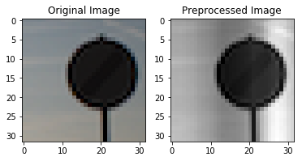

```
Original:
Class 32 -- End of all speed and passing limits
Prediction:
Class 3 -- Speed limit (60km/h)
______________________________
```

[figure not shown]

```
Original:
Class 4 -- Speed limit (70km/h)
Prediction:
Class 1 -- Speed limit (30km/h)
______________________________
```

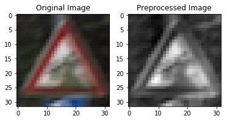

```
Original:
Class 28 -- Children crossing
Prediction:
Class 28 -- Children crossing
______________________________
```

[figure not shown]

```
Original:
Class 3 -- Speed limit (60km/h)
Prediction:
Class 2 -- Speed limit (50km/h)
______________________________
```

[figure not shown]

```
Original:
Class 13 -- Yield
Prediction:
Class 13 -- Yield
______________________________
```

[figure not shown]

```
Original:
Class 8 -- Speed limit (120km/h)
Prediction:
Class 8 -- Speed limit (120km/h)
______________________________
```

```python
saver = tf.train.Saver()

with tf.Session() as sess:
    saver.restore(sess, './lenet')

    # Test accuracy
    test_accuracy = evaluate(new_images_processed, new_images_labels)
    print("______________________________")
    print("Test Accuracy = {:.3f}".format(test_accuracy))
    print("______________________________")

    # Get predictions
    prediction = sess.run(tf.argmax(logits, 1),
                          feed_dict={x: new_images_processed,
                                     keep_prob:1.0})

    # Visualize the prediction
    fig = plt.figure(figsize=(6, 12))
    for i, img in enumerate(new_images):
        # Visualize the image
        fig = plt.figure(figsize=(6, 3))
        plt.subplot(1, 2, 1)
        plt.imshow(img)
        plt.title('Original Image')
        plt.subplot(1, 2, 2)
        img_processed = np.reshape(new_images_processed[i],(32, 32))
        plt.imshow(img_processed, cmap='gray')
        plt.title('Preprocessed Image')
        plt.show()

        # Print correct class and prediction
        class_idx = new_images_labels[i]
        print("Original:\nClass {} -- {}".format(class_idx,
                                                 sign_names_dict[class_idx]))
        prediction_class = prediction[i]
        print("Prediction:\nClass {} -- {}".format(prediction_class,
                                                   sign_names_dict[prediction_class]))
        print("______________________________")
```

#### Discussion on the prediction

The prediction got 5 out of 8 images correct: 62.5%. This is far lower than the accuracy on the test dataset: 93.7%.

This might be a problem or **precision**, but further analysis on precision and recall, especially on the test dataset is needed to draw a stronger conclusion.